# 4-1-22-DMSO

0.1% DMSO treated mODC cellls

```r
library(optimx)
library(data.table)
library(tidyverse)
library(reshape2)
library(gganimate)
library(ggridges)
library(ggpubr)
library(parallel)
```

#This is for reading in dataframes with the GFP (background and autofluor subtracted) intensities.

```r
temp1 <- read.csv("~/plots/proteasome_inhibition/data/4-1-22/DMSO/gfp_mODCPest_DMSO_filtered.csv") %>%
  mutate(exp = str_split(cell.id, pattern = "_" , simplify = TRUE)[,2]) %>%
  # filter(exp == "20min") %>%
  select(cell.id,
         delta.time,
         gfpMeanBgAFsub,
         image.no , exp.field) %>%
  split(.$cell.id)
```

Here I get the cell ids of cells which have less than 5 timepoints in my dataframe

```r
cellsWithLessThan5tps <- bind_rows(temp1) %>%
  group_by(cell.id) %>%
  tally() %>%
  filter(n < 5) %>%
  pull(cell.id)
```

#filtering the cells out which have less than 5 tps #only looking at the first 20 timepoints #only pick cellls which have all 31 timepoints

```r
cell.in.all31tp <- bind_rows(temp1) %>%
  filter(!(cell.id %in% cellsWithLessThan5tps)) %>%
  mutate(exp = str_split(exp.field, "_", simplify = T)[,1]) %>%
  filter(exp == "20min") %>%
  filter(image.no < 32) %>%
  group_by(cell.id) %>%
  tally() %>%
  filter(n == 31)

#cells with data in more than 20 images
cell.in.more.than.20 <- bind_rows(temp1) %>%
  filter(!(cell.id %in% cellsWithLessThan5tps)) %>%
  mutate(exp = str_split(exp.field, "_", simplify = T)[,1]) %>%
  filter(exp == "20min") %>%
  group_by(cell.id) %>%
  tally() %>%
  filter(n > 15)
```

Cells which have data in more than 5 timepoints

```r
gfp.filtered.cells <- bind_rows(temp1) %>%
  filter(!(cell.id %in% cellsWithLessThan5tps)) %>%
  mutate(exp = str_split(exp.field, "_", simplify = T)[,1]) %>%
  filter(exp == "20min") %>%
  split(.$cell.id)
```

remove cells which have increased gfp intensity in more than 5 timepoints

```r
cells.to.remove <- bind_rows(gfp.filtered.cells)  %>%
  group_by(cell.id) %>%
  mutate(rel.change = lead(gfpMeanBgAFsub)/lag(gfpMeanBgAFsub)) %>%
  filter(rel.change > 1,) %>%
  tally() %>%
  filter(n>5)
```

cells with data in more than 15 timepoints

```r
list.of.cells <- gfp.filtered.cells %>%
  bind_rows() %>%
  filter(cell.id %in% cell.in.more.than.20$cell.id) %>%
  split(.$cell.id)
```

|  | cell.id | delta.time | gfpMeanBgAFsub | image.no | exp.field | exp |
| --- | --- | --- | --- | --- | --- | --- |
| 1 | 1000000000_20min_s5 | 0.000 | 157.17512 | 1 | 20min_s5 | 20min |
| 2 | 1000000000_20min_s5 | 55.217 | 150.69080 | 2 | 20min_s5 | 20min |
| 3 | 1000000000_20min_s5 | 99.159 | 134.48190 | 3 | 20min_s5 | 20min |
| 4 | 1000000000_20min_s5 | 147.213 | 142.71539 | 4 | 20min_s5 | 20min |
| 5 | 1000000000_20min_s5 | 193.111 | 133.98475 | 5 | 20min_s5 | 20min |
| 6 | 1000000000_20min_s5 | 239.939 | 128.26377 | 6 | 20min_s5 | 20min |
| 7 | 1000000000_20min_s5 | 287.053 | 122.34520 | 7 | 20min_s5 | 20min |
| 8 | 1000000000_20min_s5 | 333.495 | 116.28246 | 8 | 20min_s5 | 20min |
| 9 | 1000000000_20min_s5 | 378.135 | 109.21491 | 9 | 20min_s5 | 20min |
| 10 | 1000000000_20min_s5 | 426.699 | 108.08675 | 10 | 20min_s5 | 20min |

[output cut: 21 more lines]

#saturation ODE

```r
saturation.ode <- function(t,y,parms){
  #t = time in the state
  #y = estimate of the state (gfp intensity value)
  #parms need to be a list of parameters

  #parameter values
   kd <- parms$kd
   k1 <- parms$k1

   #gfp intensities
   gfp <- y

   #ODE
   rate.gfp = -kd*gfp/(1+k1*gfp) #rate of change of gfp intensity

    return(list(rate.gfp))
  }
```

#testing how ODE works

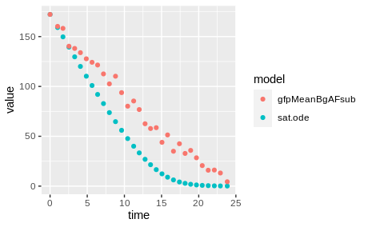

#minimization function to be used with optim

```r
sat.ode.min.fn <- function(par, df){

   #predicted values using the ODE
   sat.model <- ode(y = df$gfpMeanBgAFsub[1],
                    times = df$delta.time,
                    func = saturation.ode,
                    parms = list(kd = par[1], k1 = par[2])) %>% #estimate k1 for all the cells, so start with a fixed decay rate
     as.data.frame() %>%
     rename("sat.pred" = "1")


   df.new <- df  %>%
     mutate(model = sat.model$sat.pred/sat.model$sat.pred[1]) %>%
     mutate(error = (I0_It - model) ^ 2) %>%
     summarise(mean.error = mean(error))

    return(df.new$mean.error)
  }
```

for one cell

```r
optimx(
        par = par.optim,
        #updated this line to match the initial db with exp.field when I am optimizing in a loop
        fn = sat.ode.min.fn ,
        method = "nls",
        lower = c(0,0),
        upper = c(1,1),
        df = df.temp,
        itnmax = 100000)
```

[output not shown]

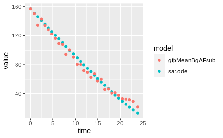

|  | cell.id | kd | k1 | value | fevals | gevals | niter | convcode | kkt1 | kkt2 | xtime |
| --- | --- | --- | --- | --- | --- | --- | --- | --- | --- | --- | --- |
| L-BFGS-B...1 | 1000000000_20min_s5 | 0.0119059911 | 0.101073578 | 0.0014347433 | 18 | 18 | NA | 0 | FALSE | FALSE | 1.431 |
| L-BFGS-B...2 | 1000000001_20min_s6 | 0.0100656935 | 0.083387648 | 0.0022012594 | 28 | 28 | NA | 0 | FALSE | FALSE | 2.051 |
| L-BFGS-B...3 | 1000000001_20min_s8 | 0.0102849227 | 0.058746653 | 0.0010996947 | 24 | 24 | NA | 0 | FALSE | FALSE | 2.774 |
| L-BFGS-B...4 | 1000000002_20min_s8 | 0.0096002431 | 0.080464592 | 0.0011078569 | 77 | 77 | NA | 0 | FALSE | TRUE | 7.970 |
| L-BFGS-B...5 | 1000000004_20min_s6 | 0.0101253043 | 0.125028510 | 0.0031353970 | 26 | 26 | NA | 0 | FALSE | TRUE | 2.116 |
| L-BFGS-B...6 | 1000000004_20min_s8 | 0.0103106531 | 0.117361577 | 0.0013912980 | 50 | 50 | NA | 0 | FALSE | TRUE | 4.683 |
| L-BFGS-B...7 | 1000000005_20min_s6 | 0.0098375505 | 0.055595154 | 0.0013714579 | 45 | 45 | NA | 52 | FALSE | FALSE | 3.856 |
| L-BFGS-B...8 | 1000000005_20min_s8 | 0.1424087733 | 1.000000000 | 0.0010508107 | 43 | 43 | NA | 0 | TRUE | TRUE | 4.514 |
| L-BFGS-B...9 | 1000000007_20min_s5 | 0.0108263404 | 0.080411141 | 0.0018508888 | 46 | 46 | NA | 52 | FALSE | FALSE | 3.951 |
| L-BFGS-B...10 | 1000000007_20min_s6 | 0.0104480102 | 0.059920495 | 0.0013033182 | 24 | 24 | NA | 0 | FALSE | FALSE | 2.045 |

[output cut: 831 more lines]

ODE predicted values

```r
ode.pred <- lapply(list.of.cells, function(a){
  ode.estimates <- single.cell.ode.est %>% filter(cell.id == a$cell.id)
  ode(y = a$gfpMeanBgAFsub[1],
                    times = a$delta.time,
                    func = saturation.ode,
                    parms = list(kd = ode.estimates$kd,
                                 k1 = ode.estimates$k1)) %>% #estimate k1 for all the cells, so start with a fixed decay rate
     as.data.frame() %>%
     rename("sat.pred" = "1")
}) %>%
  bind_rows(.id = "cell.id")
```

random cells

```r
rand.cells
```

[output not shown]

#profiles

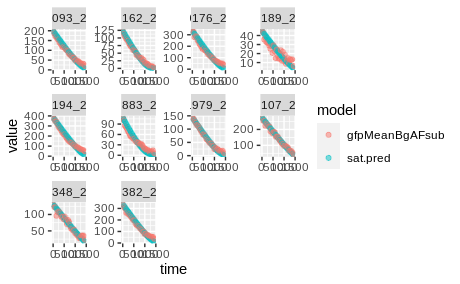

```r
ode.pred %>%
  left_join(.,bind_rows(list.of.cells) %>% rename("time" = "delta.time") %>%
              select(cell.id, gfpMeanBgAFsub, time), by = c("time", "cell.id")) %>%
  filter(cell.id %in% rand.cells) %>%
  pivot_longer(names_to = "model", cols = 3:4) %>%
  group_by(cell.id) %>%
  ggplot(.,aes(x = time, y = value, color = model))+
  geom_point(alpha = 0.5)+
  facet_wrap(~cell.id, scales = "free")
```

```r
NA
```

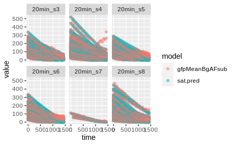

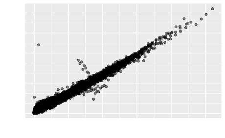

estimates vs initial gfp intensity

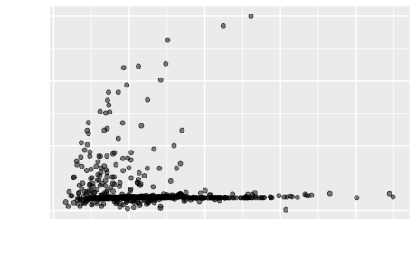

```r
single.cell.ode.est %>%
  filter(convcode == 0) %>%
  select(cell.id, kd, k1) %>%
  left_join(.,bind_rows(list.of.cells) %>%
              filter(delta.time == 0) %>%
              select(cell.id, gfpMeanBgAFsub), by = c("cell.id")) %>%
  ggplot(.,aes(x = gfpMeanBgAFsub, y = kd))+
  geom_point(alpha = 0.5)+
  stat_cor()
```

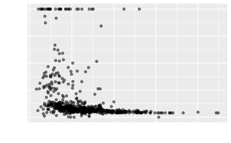

```r
single.cell.ode.est %>%
  filter(convcode == 0) %>%
  select(cell.id, kd, k1) %>%
  left_join(.,bind_rows(list.of.cells) %>%
              filter(delta.time == 0) %>%
              select(cell.id, gfpMeanBgAFsub), by = c("cell.id")) %>%
  ggplot(.,aes(x = gfpMeanBgAFsub, y = k1))+
  geom_point(alpha = 0.5)+
  stat_cor()
```

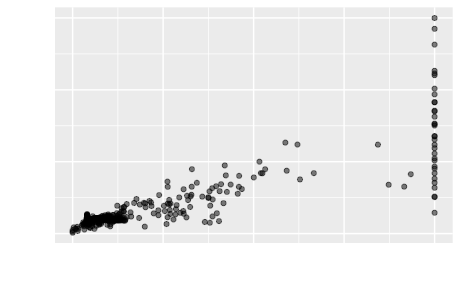

```r
single.cell.ode.est %>%
  filter(convcode == 0) %>%
  select(cell.id, kd, k1) %>%
  left_join(.,bind_rows(list.of.cells) %>%
              filter(delta.time == 0) %>%
              select(cell.id, gfpMeanBgAFsub), by = c("cell.id")) %>%
  ggplot(.,aes(x = k1, y = kd))+
  geom_point(alpha = 0.5)+
  stat_cor()
```

k1 distrbution

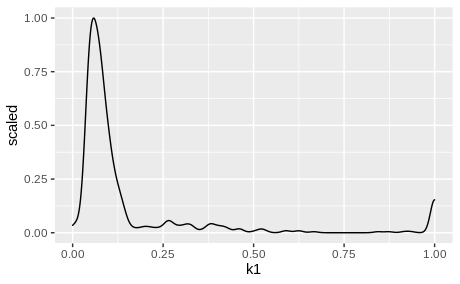

kd distribution

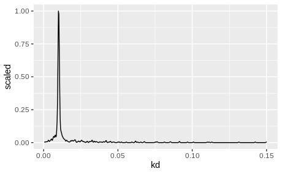

ODE in mins

```r
single.cell.ode.est.min <- mclapply(list.of.cells, function(a) {
      par.optim <- c(0.01*60, 0)

      names(par.optim) <- c("kd", "k1")

      df <- a %>%
        mutate(image.no = image.no - 1) %>%
        group_by(cell.id) %>%
        mutate(I0_It = gfpMeanBgAFsub / gfpMeanBgAFsub[1],
               delta.time = delta.time/60
        ) %>%
        ungroup()

      optimx(
        par = par.optim,
        #updated this line to match the initial db with exp.field when I am optimizing in a loop
        fn = sat.ode.min.fn ,
        method = "L-BFGS-B",
        lower = c(0, 0),
        upper = c(60,Inf),
        df = df,
        itnmax = 100000
      )
    }, mc.cores = 40) %>%
      bind_rows(.id = "cell.id")
```

ODE predicted values

```r
ode.pred.min <- lapply(list.of.cells, function(a){
  ode.estimates <- single.cell.ode.est.min %>% filter(cell.id == a$cell.id)
  ode(y = a$gfpMeanBgAFsub[1],
                    times = a$delta.time/60,
                    func = saturation.ode,
                    parms = list(kd = ode.estimates$kd,
                                 k1 = ode.estimates$k1)) %>% #estimate k1 for all the cells, so start with a fixed decay rate
     as.data.frame() %>%
     rename("sat.pred" = "1")
}) %>%
  bind_rows(.id = "cell.id")
```

profiles

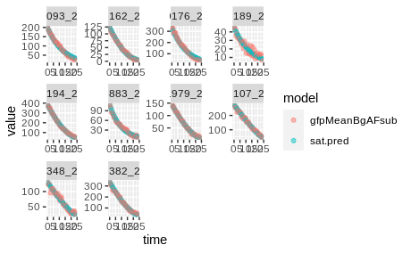

```r
ode.pred.min %>%
  left_join(.,bind_rows(list.of.cells) %>%
              rename("time" = "delta.time") %>%
              mutate(time = time/60) %>%
              select(cell.id, gfpMeanBgAFsub, time), by = c("time", "cell.id")) %>%
  filter(cell.id %in% rand.cells) %>%
  pivot_longer(names_to = "model", cols = 3:4) %>%
  group_by(cell.id) %>%
  ggplot(.,aes(x = time, y = value, color = model))+
  geom_point(alpha = 0.5)+
  facet_wrap(~cell.id, scales = "free")
```

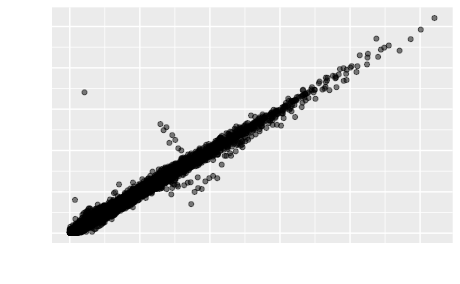

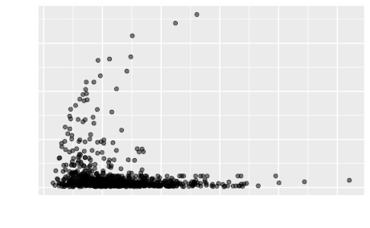

```r
#kd vs gfp
single.cell.ode.est.min %>%
  filter(convcode == 0) %>%
  select(cell.id, kd, k1) %>%
  left_join(.,bind_rows(list.of.cells) %>%
              filter(delta.time == 0) %>%
              select(cell.id, gfpMeanBgAFsub), by = c("cell.id")) %>%
  ggplot(.,aes(x = gfpMeanBgAFsub, y = kd))+
  geom_point(alpha = 0.5)+
  stat_cor()
```

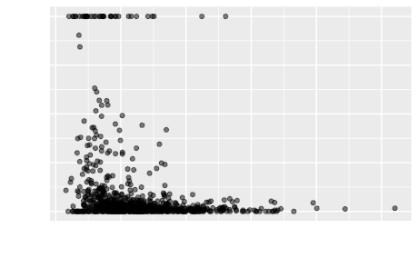

```r
#k1 vs gfp
single.cell.ode.est.min %>%
  filter(convcode == 0) %>%
  select(cell.id, kd, k1) %>%
  left_join(.,bind_rows(list.of.cells) %>%
              filter(delta.time == 0) %>%
              select(cell.id, gfpMeanBgAFsub), by = c("cell.id")) %>%
  ggplot(.,aes(x = gfpMeanBgAFsub, y = k1))+
  geom_point(alpha = 0.5)+
  stat_cor()
```

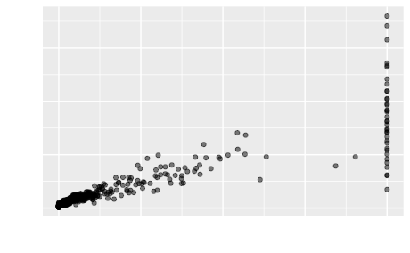

```r
#k1 vs kd
single.cell.ode.est.min %>%
  filter(convcode == 0) %>%
  select(cell.id, kd, k1) %>%
  left_join(.,bind_rows(list.of.cells) %>%
              filter(delta.time == 0) %>%
              select(cell.id, gfpMeanBgAFsub), by = c("cell.id")) %>%
  ggplot(.,aes(x = k1, y = kd))+
  geom_point(alpha = 0.5)+
  stat_cor()
```

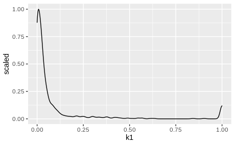

```r
#k1
single.cell.ode.est.min %>%
  filter(convcode == 0) %>%
  select(cell.id, kd, k1) %>%
  left_join(.,bind_rows(list.of.cells) %>%
              filter(delta.time == 0) %>%
              select(cell.id, gfpMeanBgAFsub), by = c("cell.id")) %>%
  ggplot(.,aes(x = k1))+
  geom_density(aes(y = ..scaled..))
```

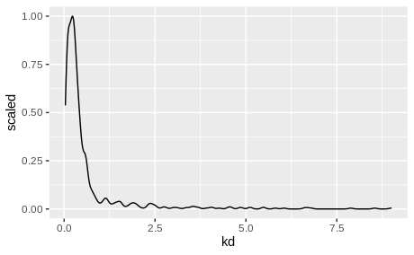

```r
#kd
single.cell.ode.est.min %>%
  filter(convcode == 0) %>%
  select(cell.id, kd, k1) %>%
  left_join(.,bind_rows(list.of.cells) %>%
              filter(delta.time == 0) %>%
              select(cell.id, gfpMeanBgAFsub), by = c("cell.id")) %>%
  ggplot(.,aes(x = kd))+
  geom_density(aes(y = ..scaled..))
```

using nls.lm for parameter estimation

```r
sat.ode.min.fn.nlsLM <- function(par, df){

   #predicted values using the ODE
   sat.model <- ode(y = df$gfpMeanBgAFsub[1],
                    times = df$delta.time,
                    func = saturation.ode,
                    parms = list(kd = par[1], k1 = par[2])) %>% #estimate k1 for all the cells, so start with a fixed decay rate
     as.data.frame() %>%
     rename("sat.pred" = "1")


   df.new <- df  %>%
     mutate(model = sat.model$sat.pred/sat.model$sat.pred[1]) %>%
     mutate(res = I0_It - model)

    return(df.new$res)
  }
```

nls.lm with initial parameters at 0.01 * 60 for kd and at 0.04 for k1

| cell.id | delta.time | gfpMeanBgAFsub | image.no | exp.field | exp | I0_It |
| --- | --- | --- | --- | --- | --- | --- |
| 1000000000_20min_s5 | 0.000 | 157.17512 | 0 | 20min_s5 | 20min | 1.0000000 |
| 1000000000_20min_s5 | 55.217 | 150.69080 | 1 | 20min_s5 | 20min | 0.9587446 |
| 1000000000_20min_s5 | 99.159 | 134.48190 | 2 | 20min_s5 | 20min | 0.8556183 |
| 1000000000_20min_s5 | 147.213 | 142.71539 | 3 | 20min_s5 | 20min | 0.9080024 |
| 1000000000_20min_s5 | 193.111 | 133.98475 | 4 | 20min_s5 | 20min | 0.8524552 |
| 1000000000_20min_s5 | 239.939 | 128.26377 | 5 | 20min_s5 | 20min | 0.8160564 |
| 1000000000_20min_s5 | 287.053 | 122.34520 | 6 | 20min_s5 | 20min | 0.7784005 |
| 1000000000_20min_s5 | 333.495 | 116.28246 | 7 | 20min_s5 | 20min | 0.7398274 |
| 1000000000_20min_s5 | 378.135 | 109.21491 | 8 | 20min_s5 | 20min | 0.6948613 |
| 1000000000_20min_s5 | 426.699 | 108.08675 | 9 | 20min_s5 | 20min | 0.6876836 |

[output cut: 21 more lines]

| cell.id | par | coefficients.Estimate | coefficients.Std..Error | coefficients.t.value | coefficients.Pr...t.. | . |
| --- | --- | --- | --- | --- | --- | --- |
| 1000000000_20min_s5 | kd | 1.517595e-01 | 1.985257e-02 | 7.644326e+00 | 1.986436e-08 | NA |
| 1000000000_20min_s5 | k1 | 1.291552e-02 | 3.029565e-03 | 4.263160e+00 | 1.949775e-04 | NA |
| 1000000001_20min_s6 | kd | 2.436229e-01 | 4.605584e-02 | 5.289728e+00 | 1.566828e-05 | NA |
| 1000000001_20min_s6 | k1 | 2.263341e-02 | 7.629545e-03 | 2.966547e+00 | 6.382396e-03 | NA |
| 1000000001_20min_s8 | kd | 2.603153e-01 | 2.663151e-02 | 9.774708e+00 | 1.103929e-10 | NA |
| 1000000001_20min_s8 | k1 | 1.795543e-02 | 3.003957e-03 | 5.977258e+00 | 1.695367e-06 | NA |
| 1000000002_20min_s8 | kd | 3.642165e-01 | 5.826733e-02 | 6.250784e+00 | 5.293901e-06 | NA |
| 1000000002_20min_s8 | k1 | 3.982816e-02 | 1.101534e-02 | 3.615698e+00 | 1.841476e-03 | NA |
| 1000000004_20min_s6 | kd | 6.669025e-01 | 3.923566e-01 | 1.699736e+00 | 1.039465e-01 | NA |
| 1000000004_20min_s6 | k1 | 1.393800e-01 | 9.937725e-02 | 1.402534e+00 | 1.753667e-01 | NA |

[output cut: 990 more lines]

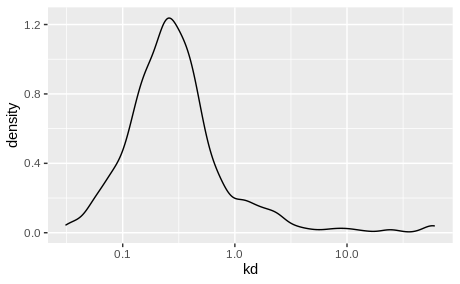

```r
temp %>%
  filter(kd < 60) %>%
  ggplot(.,aes(x = kd))+
  geom_density()+
  scale_x_log10()
```

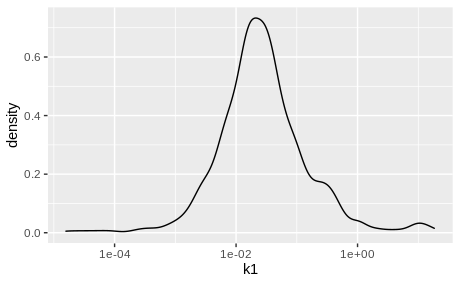

```r
temp %>%
  filter(kd < 60) %>%
  ggplot(.,aes(x = k1))+
  geom_density()+
  scale_x_log10()
```

exponential estimates using lm

| cell.id | term | estimate | std.error | statistic | p.value |
| --- | --- | --- | --- | --- | --- |
| 1000000000_20min_s5 | delta.time | -0.07091901 | 0.0013242026 | -53.556011 | 2.435948e-31 |
| 1000000001_20min_s6 | delta.time | -0.13847410 | 0.0072539415 | -19.089498 | 3.307895e-17 |
| 1000000001_20min_s8 | delta.time | -0.12796158 | 0.0052612283 | -24.321618 | 2.658206e-21 |
| 1000000002_20min_s8 | delta.time | -0.18953942 | 0.0089511990 | -21.174753 | 3.622482e-15 |
| 1000000004_20min_s6 | delta.time | -0.14454413 | 0.0086745778 | -16.662959 | 5.817759e-14 |
| 1000000004_20min_s8 | delta.time | -0.12844906 | 0.0065547647 | -19.596288 | 1.593422e-14 |
| 1000000005_20min_s6 | delta.time | -0.09908757 | 0.0031595879 | -31.360915 | 1.719056e-24 |
| 1000000005_20min_s8 | delta.time | -0.06777134 | 0.0024850290 | -27.271852 | 9.898696e-23 |
| 1000000007_20min_s5 | delta.time | -0.09215029 | 0.0020864040 | -44.167040 | 7.367405e-29 |
| 1000000007_20min_s6 | delta.time | -0.10207004 | 0.0022496902 | -45.370710 | 3.326617e-29 |

[output cut: 831 more lines]